# Risk Factor Analysis

## Outcome Variable

**Outcome Variable:** sstunted

## Predictor Variables

**Intervention Variable:** sex

**Adjustment Set:**

unadjusted

## Stratifying Variables

The analysis was stratified on these variable(s):

- agecat
- studyid

The following strata were considered:

- agecat: 12 months, studyid: ki0047075b-MAL-ED
- agecat: 12 months, studyid: ki1000108-CMC-V-BCS-2002
- agecat: 12 months, studyid: ki1000108-IRC
- agecat: 12 months, studyid: ki1000109-EE
- agecat: 12 months, studyid: ki1000109-ResPak
- agecat: 12 months, studyid: ki1000304b-SAS-FoodSuppl
- agecat: 12 months, studyid: ki1017093-NIH-Birth
- agecat: 12 months, studyid: ki1017093b-PROVIDE
- agecat: 12 months, studyid: ki1017093c-NIH-Crypto
- agecat: 12 months, studyid: ki1066203-TanzaniaChild2
- agecat: 12 months, studyid: ki1101329-Keneba
- agecat: 12 months, studyid: ki1112895-Guatemala BSC
- agecat: 12 months, studyid: ki1113344-GMS-Nepal
- agecat: 12 months, studyid: ki1114097-CMIN
- agecat: 12 months, studyid: ki1114097-CONTENT
- agecat: 12 months, studyid: ki1126311-ZVITAMBO
- agecat: 12 months, studyid: ki1135781-COHORTS
- agecat: 12 months, studyid: ki1148112-LCNI-5
- agecat: 18 months, studyid: ki0047075b-MAL-ED
- agecat: 18 months, studyid: ki1000108-CMC-V-BCS-2002
- agecat: 18 months, studyid: ki1000108-IRC
- agecat: 18 months, studyid: ki1000109-EE
- agecat: 18 months, studyid: ki1000109-ResPak
- agecat: 18 months, studyid: ki1000304b-SAS-FoodSuppl
- agecat: 18 months, studyid: ki1017093-NIH-Birth
- agecat: 18 months, studyid: ki1017093b-PROVIDE
- agecat: 18 months, studyid: ki1017093c-NIH-Crypto
- agecat: 18 months, studyid: ki1066203-TanzaniaChild2
- agecat: 18 months, studyid: ki1101329-Keneba
- agecat: 18 months, studyid: ki1113344-GMS-Nepal
- agecat: 18 months, studyid: ki1114097-CMIN
- agecat: 18 months, studyid: ki1114097-CONTENT
- agecat: 18 months, studyid: ki1126311-ZVITAMBO
- agecat: 18 months, studyid: ki1135781-COHORTS
- agecat: 18 months, studyid: ki1148112-LCNI-5
- agecat: 24 months, studyid: ki0047075b-MAL-ED
- agecat: 24 months, studyid: ki1000108-CMC-V-BCS-2002
- agecat: 24 months, studyid: ki1000108-IRC
- agecat: 24 months, studyid: ki1017093-NIH-Birth
- agecat: 24 months, studyid: ki1017093b-PROVIDE
- agecat: 24 months, studyid: ki1017093c-NIH-Crypto
- agecat: 24 months, studyid: ki1066203-TanzaniaChild2
- agecat: 24 months, studyid: ki1101329-Keneba
- agecat: 24 months, studyid: ki1113344-GMS-Nepal
- agecat: 24 months, studyid: ki1114097-CMIN
- agecat: 24 months, studyid: ki1114097-CONTENT
- agecat: 24 months, studyid: ki1126311-ZVITAMBO
- agecat: 24 months, studyid: ki1135781-COHORTS
- agecat: 24 months, studyid: ki1148112-LCNI-5
- agecat: 3 months, studyid: ki0047075b-MAL-ED
- agecat: 3 months, studyid: ki1000108-CMC-V-BCS-2002
- agecat: 3 months, studyid: ki1000108-IRC
- agecat: 3 months, studyid: ki1000109-EE
- agecat: 3 months, studyid: ki1000109-ResPak
- agecat: 3 months, studyid: ki1000304b-SAS-FoodSuppl
- agecat: 3 months, studyid: ki1017093-NIH-Birth
- agecat: 3 months, studyid: ki1017093b-PROVIDE
- agecat: 3 months, studyid: ki1017093c-NIH-Crypto
- agecat: 3 months, studyid: ki1066203-TanzaniaChild2
- agecat: 3 months, studyid: ki1101329-Keneba
- agecat: 3 months, studyid: ki1112895-Guatemala BSC
- agecat: 3 months, studyid: ki1113344-GMS-Nepal
- agecat: 3 months, studyid: ki1114097-CMIN
- agecat: 3 months, studyid: ki1114097-CONTENT
- agecat: 3 months, studyid: ki1126311-ZVITAMBO
- agecat: 3 months, studyid: ki1135781-COHORTS
- agecat: 6 months, studyid: ki0047075b-MAL-ED
- agecat: 6 months, studyid: ki1000108-CMC-V-BCS-2002
- agecat: 6 months, studyid: ki1000108-IRC
- agecat: 6 months, studyid: ki1000109-EE
- agecat: 6 months, studyid: ki1000109-ResPak
- agecat: 6 months, studyid: ki1000304b-SAS-FoodSuppl
- agecat: 6 months, studyid: ki1017093-NIH-Birth
- agecat: 6 months, studyid: ki1017093b-PROVIDE
- agecat: 6 months, studyid: ki1017093c-NIH-Crypto
- agecat: 6 months, studyid: ki1066203-TanzaniaChild2
- agecat: 6 months, studyid: ki1101329-Keneba
- agecat: 6 months, studyid: ki1112895-Guatemala BSC
- agecat: 6 months, studyid: ki1113344-GMS-Nepal
- agecat: 6 months, studyid: ki1114097-CMIN
- agecat: 6 months, studyid: ki1114097-CONTENT
- agecat: 6 months, studyid: ki1126311-ZVITAMBO
- agecat: 6 months, studyid: ki1135781-COHORTS
- agecat: 6 months, studyid: ki1148112-LCNI-5
- agecat: 9 months, studyid: ki0047075b-MAL-ED
- agecat: 9 months, studyid: ki1000108-CMC-V-BCS-2002
- agecat: 9 months, studyid: ki1000108-IRC
- agecat: 9 months, studyid: ki1000109-EE
- agecat: 9 months, studyid: ki1000109-ResPak
- agecat: 9 months, studyid: ki1000304b-SAS-FoodSuppl
- agecat: 9 months, studyid: ki1017093-NIH-Birth
- agecat: 9 months, studyid: ki1017093b-PROVIDE
- agecat: 9 months, studyid: ki1017093c-NIH-Crypto
- agecat: 9 months, studyid: ki1066203-TanzaniaChild2
- agecat: 9 months, studyid: ki1101329-Keneba
- agecat: 9 months, studyid: ki1112895-Guatemala BSC
- agecat: 9 months, studyid: ki1113344-GMS-Nepal
- agecat: 9 months, studyid: ki1114097-CMIN
- agecat: 9 months, studyid: ki1114097-CONTENT
- agecat: 9 months, studyid: ki1126311-ZVITAMBO
- agecat: 9 months, studyid: ki1135781-COHORTS
- agecat: 9 months, studyid: ki1148112-LCNI-5
- agecat: Birth, studyid: ki0047075b-MAL-ED
- agecat: Birth, studyid: ki1000108-CMC-V-BCS-2002
- agecat: Birth, studyid: ki1000108-IRC
- agecat: Birth, studyid: ki1000109-EE
- agecat: Birth, studyid: ki1000109-ResPak
- agecat: Birth, studyid: ki1017093-NIH-Birth
- agecat: Birth, studyid: ki1017093c-NIH-Crypto
- agecat: Birth, studyid: ki1101329-Keneba
- agecat: Birth, studyid: ki1114097-CMIN
- agecat: Birth, studyid: ki1114097-CONTENT
- agecat: Birth, studyid: ki1126311-ZVITAMBO
- agecat: Birth, studyid: ki1135781-COHORTS

### Dropped Strata

Some strata were dropped due to rare outcomes:

- agecat: Birth, studyid: ki1000108-CMC-V-BCS-2002
- agecat: Birth, studyid: ki1000109-EE
- agecat: Birth, studyid: ki1000109-ResPak
- agecat: Birth, studyid: ki1017093-NIH-Birth
- agecat: Birth, studyid: ki1017093c-NIH-Crypto
- agecat: Birth, studyid: ki1114097-CMIN
- agecat: Birth, studyid: ki1114097-CONTENT
- agecat: 3 months, studyid: ki1017093b-PROVIDE
- agecat: 3 months, studyid: ki1066203-TanzaniaChild2
- agecat: 3 months, studyid: ki1112895-Guatemala BSC
- agecat: 3 months, studyid: ki1114097-CONTENT
- agecat: 6 months, studyid: ki1017093b-PROVIDE
- agecat: 6 months, studyid: ki1066203-TanzaniaChild2
- agecat: 6 months, studyid: ki1112895-Guatemala BSC
- agecat: 6 months, studyid: ki1113344-GMS-Nepal
- agecat: 6 months, studyid: ki1114097-CONTENT
- agecat: 9 months, studyid: ki1017093b-PROVIDE
- agecat: 9 months, studyid: ki1066203-TanzaniaChild2
- agecat: 9 months, studyid: ki1112895-Guatemala BSC
- agecat: 9 months, studyid: ki1114097-CONTENT
- agecat: 12 months, studyid: ki1017093b-PROVIDE
- agecat: 12 months, studyid: ki1066203-TanzaniaChild2
- agecat: 12 months, studyid: ki1112895-Guatemala BSC
- agecat: 12 months, studyid: ki1114097-CONTENT
- agecat: 18 months, studyid: ki1000109-ResPak
- agecat: 18 months, studyid: ki1066203-TanzaniaChild2
- agecat: 18 months, studyid: ki1114097-CONTENT
- agecat: 24 months, studyid: ki1017093b-PROVIDE
- agecat: 24 months, studyid: ki1066203-TanzaniaChild2
- agecat: 24 months, studyid: ki1114097-CONTENT

## Methods Detail

We’re interested in the causal parameters $E[Y_a]$ for all values of $a \in \mathcal{A}$. These parameters represent the mean outcome if, possibly contrary to fact, we intervened to set all units to have $A=a$. Under the randomization and positivity assumptions, these are identified by the statistical parameters $\psi_a=E_W[E_{Y|A,W}(Y|A=a,W)]$. In addition, we’re interested in the mean of $Y$, $E[Y]$ under no intervention (the observed mean). We will estimate these parameters by using SuperLearner to fit the relevant likelihood factors – $E_{Y|A,W}(Y|A=a,W)$ and $p(A=a|W)$, and then updating our likelihood fit using a joint TMLE.

For unadjusted analyses ($W=\{\}$), initial likelihoods were estimated using Lrnr_glm to estimate the simple $E(Y|A)$ and Lrnr_mean to estimate $p(A)$. For adjusted analyses, a small library containing Lrnr_glmnet, Lrnr_xgboost, and Lrnr_mean was used.

Having estimated these parameters, we will then use the delta method to estimate relative risks and attributable risks relative to a prespecified baseline level of $A$.

# Results Detail

## Results Plots

[figure not shown]

[figure not shown]

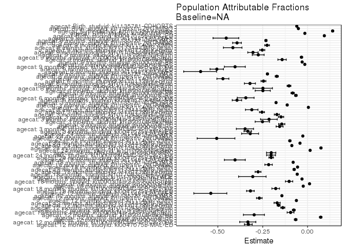

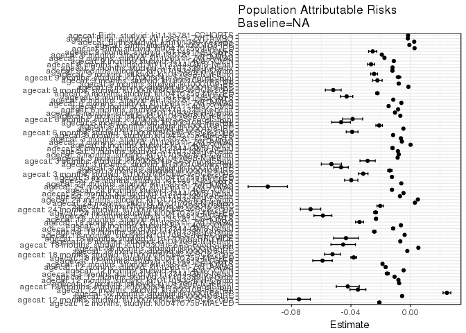

## Data Summary

| agecat | studyid | A | n | nA | nAY0 | nAY1 |
| --- | --- | --- | --- | --- | --- | --- |
| Birth | ki0047075b-MAL-ED | Female | 1499 | 744 | 719 | 25 |
| Birth | ki0047075b-MAL-ED | Male | 1499 | 755 | 734 | 21 |
| Birth | ki1000108-CMC-V-BCS-2002 | Female | 90 | 45 | 44 | 1 |
| Birth | ki1000108-CMC-V-BCS-2002 | Male | 90 | 45 | 43 | 2 |
| Birth | ki1000108-IRC | Female | 388 | 173 | 166 | 7 |
| Birth | ki1000108-IRC | Male | 388 | 215 | 206 | 9 |
| Birth | ki1000109-EE | Female | 2 | 0 | 0 | 0 |
| Birth | ki1000109-EE | Male | 2 | 2 | 2 | 0 |
| Birth | ki1000109-ResPak | Female | 7 | 3 | 3 | 0 |
| Birth | ki1000109-ResPak | Male | 7 | 4 | 4 | 0 |
| Birth | ki1000304b-SAS-FoodSuppl | Female | 0 | 0 | 0 | 0 |
| Birth | ki1000304b-SAS-FoodSuppl | Male | 0 | 0 | 0 | 0 |
| Birth | ki1017093-NIH-Birth | Female | 28 | 12 | 12 | 0 |
| Birth | ki1017093-NIH-Birth | Male | 28 | 16 | 16 | 0 |
| Birth | ki1017093b-PROVIDE | Female | 0 | 0 | 0 | 0 |
| Birth | ki1017093b-PROVIDE | Male | 0 | 0 | 0 | 0 |
| Birth | ki1017093c-NIH-Crypto | Female | 27 | 13 | 12 | 1 |
| Birth | ki1017093c-NIH-Crypto | Male | 27 | 14 | 14 | 0 |
| Birth | ki1066203-TanzaniaChild2 | Female | 0 | 0 | 0 | 0 |
| Birth | ki1066203-TanzaniaChild2 | Male | 0 | 0 | 0 | 0 |
| Birth | ki1101329-Keneba | Female | 1541 | 738 | 722 | 16 |
| Birth | ki1101329-Keneba | Male | 1541 | 803 | 790 | 13 |
| Birth | ki1112895-Guatemala BSC | Female | 0 | 0 | 0 | 0 |
| Birth | ki1112895-Guatemala BSC | Male | 0 | 0 | 0 | 0 |
| Birth | ki1113344-GMS-Nepal | Female | 0 | 0 | 0 | 0 |
| Birth | ki1113344-GMS-Nepal | Male | 0 | 0 | 0 | 0 |
| Birth | ki1114097-CMIN | Female | 138 | 72 | 70 | 2 |
| Birth | ki1114097-CMIN | Male | 138 | 66 | 60 | 6 |
| Birth | ki1114097-CONTENT | Female | 2 | 2 | 2 | 0 |
| Birth | ki1114097-CONTENT | Male | 2 | 0 | 0 | 0 |

[output cut: 222 more lines]

## Results Table

### Parameter: TSM

| agecat | studyid | intervention_level | baseline_level | estimate | ci_lower | ci_upper |
| --- | --- | --- | --- | --- | --- | --- |
| Birth | ki0047075b-MAL-ED | NA | NA | 0.0278146 | 0.0278146 | 0.0278146 |
| Birth | ki0047075b-MAL-ED | Female | NA | 0.0336022 | 0.0206492 | 0.0465551 |
| Birth | ki0047075b-MAL-ED | Male | NA | 0.0278146 | 0.0160810 | 0.0395481 |
| Birth | ki1000108-IRC | NA | NA | 0.0418605 | 0.0418605 | 0.0418605 |
| Birth | ki1000108-IRC | Female | NA | 0.0404624 | 0.0110628 | 0.0698621 |
| Birth | ki1000108-IRC | Male | NA | 0.0418605 | 0.0150561 | 0.0686648 |
| Birth | ki1101329-Keneba | NA | NA | 0.0161893 | 0.0161893 | 0.0161893 |
| Birth | ki1101329-Keneba | Female | NA | 0.0216802 | 0.0111695 | 0.0321910 |
| Birth | ki1101329-Keneba | Male | NA | 0.0161893 | 0.0074575 | 0.0249210 |
| Birth | ki1126311-ZVITAMBO | NA | NA | 0.0341354 | 0.0341354 | 0.0341354 |
| Birth | ki1126311-ZVITAMBO | Female | NA | 0.0306859 | 0.0223932 | 0.0389786 |
| Birth | ki1126311-ZVITAMBO | Male | NA | 0.0341354 | 0.0257155 | 0.0425554 |
| Birth | ki1135781-COHORTS | NA | NA | 0.0268787 | 0.0268787 | 0.0268787 |
| Birth | ki1135781-COHORTS | Female | NA | 0.0236809 | 0.0193854 | 0.0279764 |
| Birth | ki1135781-COHORTS | Male | NA | 0.0268787 | 0.0225174 | 0.0312400 |
| 3 months | ki0047075b-MAL-ED | NA | NA | 0.0494938 | 0.0494938 | 0.0494938 |
| 3 months | ki0047075b-MAL-ED | Female | NA | 0.0247469 | 0.0145319 | 0.0349619 |
| 3 months | ki0047075b-MAL-ED | Male | NA | 0.0494938 | 0.0352321 | 0.0637555 |
| 3 months | ki1000108-CMC-V-BCS-2002 | NA | NA | 0.1229050 | 0.1229050 | 0.1229050 |
| 3 months | ki1000108-CMC-V-BCS-2002 | Female | NA | 0.0601093 | 0.0256241 | 0.0945945 |
| 3 months | ki1000108-CMC-V-BCS-2002 | Male | NA | 0.1229050 | 0.0747402 | 0.1710699 |
| 3 months | ki1000108-IRC | NA | NA | 0.1022222 | 0.1022222 | 0.1022222 |
| 3 months | ki1000108-IRC | Female | NA | 0.0714286 | 0.0339666 | 0.1088905 |
| 3 months | ki1000108-IRC | Male | NA | 0.1022222 | 0.0625900 | 0.1418544 |
| 3 months | ki1000109-EE | NA | NA | 0.3711340 | 0.3711340 | 0.3711340 |
| 3 months | ki1000109-EE | Female | NA | 0.2747253 | 0.2097884 | 0.3396621 |
| 3 months | ki1000109-EE | Male | NA | 0.3711340 | 0.3030618 | 0.4392062 |
| 3 months | ki1000109-ResPak | NA | NA | 0.2647059 | 0.2647059 | 0.2647059 |
| 3 months | ki1000109-ResPak | Female | NA | 0.1532258 | 0.0897039 | 0.2167478 |
| 3 months | ki1000109-ResPak | Male | NA | 0.2647059 | 0.1904163 | 0.3389954 |

[output cut: 222 more lines]

### Parameter: E(Y)

| agecat | studyid | intervention_level | baseline_level | estimate | ci_lower | ci_upper |
| --- | --- | --- | --- | --- | --- | --- |
| Birth | ki0047075b-MAL-ED | NA | NA | 0.0306871 | 0.0305406 | 0.0308337 |
| Birth | ki1000108-IRC | NA | NA | 0.0412371 | 0.0411679 | 0.0413063 |
| Birth | ki1101329-Keneba | NA | NA | 0.0188189 | 0.0186819 | 0.0189559 |
| Birth | ki1126311-ZVITAMBO | NA | NA | 0.0324732 | 0.0324156 | 0.0325307 |
| Birth | ki1135781-COHORTS | NA | NA | 0.0253541 | 0.0253229 | 0.0253852 |
| 3 months | ki0047075b-MAL-ED | NA | NA | 0.0371204 | 0.0365451 | 0.0376957 |
| 3 months | ki1000108-CMC-V-BCS-2002 | NA | NA | 0.0911602 | 0.0879215 | 0.0943989 |
| 3 months | ki1000108-IRC | NA | NA | 0.0884521 | 0.0869628 | 0.0899414 |
| 3 months | ki1000109-EE | NA | NA | 0.3244681 | 0.3195917 | 0.3293445 |
| 3 months | ki1000109-ResPak | NA | NA | 0.2115385 | 0.2047573 | 0.2183196 |
| 3 months | ki1000304b-SAS-FoodSuppl | NA | NA | 0.1340206 | 0.1288850 | 0.1391562 |
| 3 months | ki1017093-NIH-Birth | NA | NA | 0.0578947 | 0.0571516 | 0.0586379 |
| 3 months | ki1017093c-NIH-Crypto | NA | NA | 0.0453297 | 0.0447760 | 0.0458833 |
| 3 months | ki1101329-Keneba | NA | NA | 0.0328767 | 0.0325122 | 0.0332412 |
| 3 months | ki1113344-GMS-Nepal | NA | NA | 0.0385289 | 0.0375053 | 0.0395525 |
| 3 months | ki1114097-CMIN | NA | NA | 0.0417508 | 0.0417407 | 0.0417610 |
| 3 months | ki1126311-ZVITAMBO | NA | NA | 0.0501982 | 0.0499583 | 0.0504380 |
| 3 months | ki1135781-COHORTS | NA | NA | 0.0361318 | 0.0360043 | 0.0362592 |
| 6 months | ki0047075b-MAL-ED | NA | NA | 0.0294811 | 0.0289264 | 0.0300359 |
| 6 months | ki1000108-CMC-V-BCS-2002 | NA | NA | 0.1138211 | 0.1098501 | 0.1177922 |
| 6 months | ki1000108-IRC | NA | NA | 0.0712531 | 0.0707537 | 0.0717524 |
| 6 months | ki1000109-EE | NA | NA | 0.2526882 | 0.2505052 | 0.2548711 |
| 6 months | ki1000109-ResPak | NA | NA | 0.1872340 | 0.1809184 | 0.1935497 |
| 6 months | ki1000304b-SAS-FoodSuppl | NA | NA | 0.1562500 | 0.1495011 | 0.1629989 |
| 6 months | ki1017093-NIH-Birth | NA | NA | 0.0651769 | 0.0645539 | 0.0657999 |
| 6 months | ki1017093c-NIH-Crypto | NA | NA | 0.0321678 | 0.0314200 | 0.0329157 |
| 6 months | ki1101329-Keneba | NA | NA | 0.0335089 | 0.0331441 | 0.0338736 |
| 6 months | ki1114097-CMIN | NA | NA | 0.0310458 | 0.0303420 | 0.0317495 |
| 6 months | ki1126311-ZVITAMBO | NA | NA | 0.0350877 | 0.0348220 | 0.0353534 |
| 6 months | ki1135781-COHORTS | NA | NA | 0.0513357 | 0.0511001 | 0.0515714 |

[output cut: 54 more lines]

### Parameter: RR

| agecat | studyid | intervention_level | baseline_level | estimate | ci_lower | ci_upper |
| --- | --- | --- | --- | --- | --- | --- |
| Birth | ki0047075b-MAL-ED | Female | NA | 1.2080773 | 0.8216431 | 1.7762587 |
| Birth | ki0047075b-MAL-ED | Male | NA | 1.0000000 | 0.6558325 | 1.5247796 |
| Birth | ki1000108-IRC | Female | NA | 0.9666024 | 0.4674047 | 1.9989534 |
| Birth | ki1000108-IRC | Male | NA | 1.0000000 | 0.5271202 | 1.8971005 |
| Birth | ki1101329-Keneba | Female | NA | 1.3391703 | 0.8246820 | 2.1746287 |
| Birth | ki1101329-Keneba | Male | NA | 1.0000000 | 0.5831254 | 1.7148971 |
| Birth | ki1126311-ZVITAMBO | Female | NA | 0.8989466 | 0.6860690 | 1.1778770 |
| Birth | ki1126311-ZVITAMBO | Male | NA | 1.0000000 | 0.7814039 | 1.2797479 |
| Birth | ki1135781-COHORTS | Female | NA | 0.8810307 | 0.7348766 | 1.0562523 |
| Birth | ki1135781-COHORTS | Male | NA | 1.0000000 | 0.8502209 | 1.1761649 |
| 3 months | ki0047075b-MAL-ED | Female | NA | 0.5000000 | 0.3309043 | 0.7555055 |
| 3 months | ki0047075b-MAL-ED | Male | NA | 1.0000000 | 0.7496478 | 1.3339598 |
| 3 months | ki1000108-CMC-V-BCS-2002 | Female | NA | 0.4890710 | 0.2755584 | 0.8680211 |
| 3 months | ki1000108-CMC-V-BCS-2002 | Male | NA | 1.0000000 | 0.6757805 | 1.4797703 |
| 3 months | ki1000108-IRC | Female | NA | 0.6987578 | 0.4135742 | 1.1805920 |
| 3 months | ki1000108-IRC | Male | NA | 1.0000000 | 0.6786117 | 1.4735968 |
| 3 months | ki1000109-EE | Female | NA | 0.7402320 | 0.5844046 | 0.9376097 |
| 3 months | ki1000109-EE | Male | NA | 1.0000000 | 0.8324211 | 1.2013150 |
| 3 months | ki1000109-ResPak | Female | NA | 0.5788530 | 0.3824066 | 0.8762163 |
| 3 months | ki1000109-ResPak | Male | NA | 1.0000000 | 0.7552931 | 1.3239894 |
| 3 months | ki1000304b-SAS-FoodSuppl | Female | NA | 0.6825397 | 0.3197410 | 1.4569931 |
| 3 months | ki1000304b-SAS-FoodSuppl | Male | NA | 1.0000000 | 0.5059366 | 1.9765321 |
| 3 months | ki1017093-NIH-Birth | Female | NA | 0.7273234 | 0.4277792 | 1.2366178 |
| 3 months | ki1017093-NIH-Birth | Male | NA | 1.0000000 | 0.6545399 | 1.5277908 |
| 3 months | ki1017093c-NIH-Crypto | Female | NA | 0.7129445 | 0.4263385 | 1.1922214 |
| 3 months | ki1017093c-NIH-Crypto | Male | NA | 1.0000000 | 0.6454208 | 1.5493768 |
| 3 months | ki1101329-Keneba | Female | NA | 0.5775076 | 0.3920287 | 0.8507414 |
| 3 months | ki1101329-Keneba | Male | NA | 1.0000000 | 0.7557847 | 1.3231281 |
| 3 months | ki1113344-GMS-Nepal | Female | NA | 0.5058394 | 0.2433024 | 1.0516685 |
| 3 months | ki1113344-GMS-Nepal | Male | NA | 1.0000000 | 0.6104566 | 1.6381180 |

[output cut: 138 more lines]

### Parameter: PAR

| agecat | studyid | intervention_level | baseline_level | estimate | ci_lower | ci_upper |
| --- | --- | --- | --- | --- | --- | --- |
| Birth | ki0047075b-MAL-ED | NA | NA | 0.0028726 | 0.0027260 | 0.0030191 |
| Birth | ki1000108-IRC | NA | NA | -0.0006234 | -0.0006926 | -0.0005541 |
| Birth | ki1101329-Keneba | NA | NA | 0.0026297 | 0.0024927 | 0.0027667 |
| Birth | ki1126311-ZVITAMBO | NA | NA | -0.0016622 | -0.0017198 | -0.0016047 |
| Birth | ki1135781-COHORTS | NA | NA | -0.0015246 | -0.0015558 | -0.0014934 |
| 3 months | ki0047075b-MAL-ED | NA | NA | -0.0123735 | -0.0129488 | -0.0117982 |
| 3 months | ki1000108-CMC-V-BCS-2002 | NA | NA | -0.0317448 | -0.0349835 | -0.0285061 |
| 3 months | ki1000108-IRC | NA | NA | -0.0137701 | -0.0152594 | -0.0122808 |
| 3 months | ki1000109-EE | NA | NA | -0.0466659 | -0.0515423 | -0.0417896 |
| 3 months | ki1000109-ResPak | NA | NA | -0.0531674 | -0.0599486 | -0.0463863 |
| 3 months | ki1000304b-SAS-FoodSuppl | NA | NA | -0.0287701 | -0.0339057 | -0.0236345 |
| 3 months | ki1017093-NIH-Birth | NA | NA | -0.0085504 | -0.0092936 | -0.0078073 |
| 3 months | ki1017093c-NIH-Crypto | NA | NA | -0.0077430 | -0.0082966 | -0.0071893 |
| 3 months | ki1101329-Keneba | NA | NA | -0.0083514 | -0.0087159 | -0.0079868 |
| 3 months | ki1113344-GMS-Nepal | NA | NA | -0.0119762 | -0.0129998 | -0.0109526 |
| 3 months | ki1114097-CMIN | NA | NA | 0.0001924 | 0.0001822 | 0.0002026 |
| 3 months | ki1126311-ZVITAMBO | NA | NA | -0.0056918 | -0.0059317 | -0.0054519 |
| 3 months | ki1135781-COHORTS | NA | NA | -0.0063464 | -0.0064739 | -0.0062190 |
| 6 months | ki0047075b-MAL-ED | NA | NA | -0.0115987 | -0.0121535 | -0.0110439 |
| 6 months | ki1000108-CMC-V-BCS-2002 | NA | NA | -0.0391843 | -0.0431554 | -0.0352133 |
| 6 months | ki1000108-IRC | NA | NA | -0.0046398 | -0.0051391 | -0.0041405 |
| 6 months | ki1000109-EE | NA | NA | -0.0209960 | -0.0231790 | -0.0188131 |
| 6 months | ki1000109-ResPak | NA | NA | -0.0466369 | -0.0529526 | -0.0403213 |
| 6 months | ki1000304b-SAS-FoodSuppl | NA | NA | -0.0388720 | -0.0456209 | -0.0321230 |
| 6 months | ki1017093-NIH-Birth | NA | NA | -0.0067409 | -0.0073639 | -0.0061179 |
| 6 months | ki1017093c-NIH-Crypto | NA | NA | -0.0103251 | -0.0110730 | -0.0095772 |
| 6 months | ki1101329-Keneba | NA | NA | -0.0082351 | -0.0085999 | -0.0078704 |
| 6 months | ki1114097-CMIN | NA | NA | -0.0146448 | -0.0153486 | -0.0139410 |
| 6 months | ki1126311-ZVITAMBO | NA | NA | -0.0060213 | -0.0062870 | -0.0057555 |
| 6 months | ki1135781-COHORTS | NA | NA | -0.0114855 | -0.0117212 | -0.0112499 |

[output cut: 54 more lines]

### Parameter: PAF

| agecat | studyid | intervention_level | baseline_level | estimate | ci_lower | ci_upper |
| --- | --- | --- | --- | --- | --- | --- |
| Birth | ki0047075b-MAL-ED | NA | NA | 0.0936078 | 0.0892693 | 0.0979257 |
| Birth | ki1000108-IRC | NA | NA | -0.0151163 | -0.0168220 | -0.0134134 |
| Birth | ki1101329-Keneba | NA | NA | 0.1397346 | 0.1334492 | 0.1459745 |
| Birth | ki1126311-ZVITAMBO | NA | NA | -0.0511881 | -0.0530521 | -0.0493274 |
| Birth | ki1135781-COHORTS | NA | NA | -0.0601324 | -0.0614359 | -0.0588306 |
| 3 months | ki0047075b-MAL-ED | NA | NA | -0.3333333 | -0.3541586 | -0.3128283 |
| 3 months | ki1000108-CMC-V-BCS-2002 | NA | NA | -0.3482309 | -0.3969910 | -0.3011727 |
| 3 months | ki1000108-IRC | NA | NA | -0.1556790 | -0.1753022 | -0.1363835 |
| 3 months | ki1000109-EE | NA | NA | -0.1438229 | -0.1611430 | -0.1267611 |
| 3 months | ki1000109-ResPak | NA | NA | -0.2513369 | -0.2921000 | -0.2118598 |
| 3 months | ki1000304b-SAS-FoodSuppl | NA | NA | -0.2146691 | -0.2621178 | -0.1690041 |
| 3 months | ki1017093-NIH-Birth | NA | NA | -0.1476895 | -0.1625169 | -0.1330513 |
| 3 months | ki1017093c-NIH-Crypto | NA | NA | -0.1708143 | -0.1852019 | -0.1566013 |
| 3 months | ki1101329-Keneba | NA | NA | -0.2540205 | -0.2680024 | -0.2401927 |
| 3 months | ki1113344-GMS-Nepal | NA | NA | -0.3108356 | -0.3461275 | -0.2764690 |
| 3 months | ki1114097-CMIN | NA | NA | 0.0046083 | 0.0043661 | 0.0048505 |
| 3 months | ki1126311-ZVITAMBO | NA | NA | -0.1133864 | -0.1187198 | -0.1080785 |
| 3 months | ki1135781-COHORTS | NA | NA | -0.1756468 | -0.1798016 | -0.1715066 |
| 6 months | ki0047075b-MAL-ED | NA | NA | -0.3934272 | -0.4198972 | -0.3674507 |
| 6 months | ki1000108-CMC-V-BCS-2002 | NA | NA | -0.3442623 | -0.3919894 | -0.2981716 |
| 6 months | ki1000108-IRC | NA | NA | -0.0651170 | -0.0726073 | -0.0576790 |
| 6 months | ki1000109-EE | NA | NA | -0.0830907 | -0.0924879 | -0.0737744 |
| 6 months | ki1000109-ResPak | NA | NA | -0.2490836 | -0.2919356 | -0.2076529 |
| 6 months | ki1000304b-SAS-FoodSuppl | NA | NA | -0.2487805 | -0.3039009 | -0.1959902 |
| 6 months | ki1017093-NIH-Birth | NA | NA | -0.1034247 | -0.1140225 | -0.0929276 |
| 6 months | ki1017093c-NIH-Crypto | NA | NA | -0.3209755 | -0.3520466 | -0.2906184 |
| 6 months | ki1101329-Keneba | NA | NA | -0.2457593 | -0.2593934 | -0.2322728 |
| 6 months | ki1114097-CMIN | NA | NA | -0.4717167 | -0.5054589 | -0.4387308 |
| 6 months | ki1126311-ZVITAMBO | NA | NA | -0.1716061 | -0.1805123 | -0.1627671 |
| 6 months | ki1135781-COHORTS | NA | NA | -0.2237335 | -0.2293637 | -0.2181290 |

[output cut: 54 more lines]